# **Second Markdown Assignment**

Adrian Enrico Rodriguez, Gian Carlo Fernandez, Iris Salangad, John Kyle Lluz

7/16/2021

# The Monty Hall Problem and the PCSO Ultra Lotto 6/58

## Monty Hall

### *Insights and solution to the Monty Hall Problem*

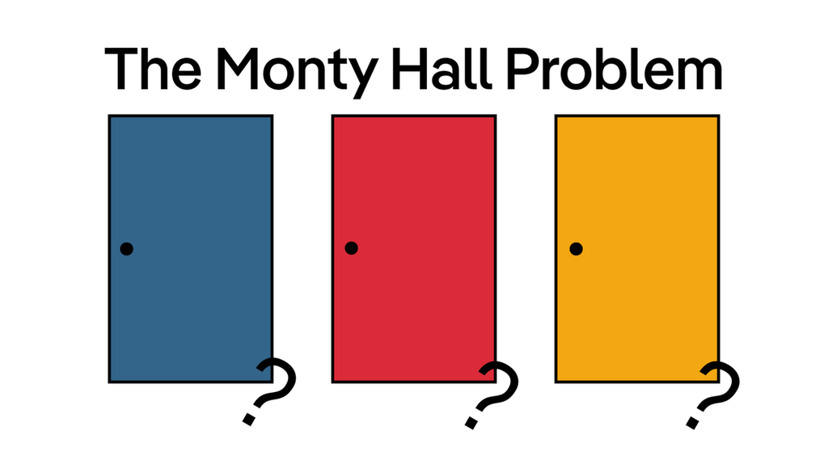

The Monty Hall Problem is a game from *Video Village*, a show hosted by Monty Hall himself in which the players are to pick from the given 3 doors. **1 door has a major prize while the other 2 have no prizes.** When the player picks a door, Monty Hall then opens another door not picked by the player and asks if the player is going to stay or switch to another door. A debate then arises **whether or not it is better to switch or to stay.**

When we use probability, we will be able to derive the chances of winning or losing if the player switches a door or stays at their first pick.

The game starts with all three doors closed and no information is given. When a player picks a door, since there is only one prize but 3 outcomes, **this gives us an equal chance of winning with ⅓ each door.**

After selecting door 1 in each scenario, **there are three possible arrangements of one Rico (prize)** and **two Chocnuts behind three doors,** as well as the outcome of remaining or switching after first picking door 1.

**CASE 1:** If the Chocnut is behind doors 1 and 2, we can say that Rico is behind door 3. If we remain to stay at the door #1, the prize that we’ll win is Chocnut. However, **if we switch to the door offered, we’ll be able to win Rico.**

[figure not shown]

**CASE 2:** If the Chocnut is behind doors 1 and 3, we can say that Rico is behind door 2. If we remain to stay at the door #1, the prize that we’ll win is Chocnut. However, **if we switch to the door offered, we’ll be able to win Rico.**

[figure not shown]

**CASE 3:** If the Chocnut is behind doors 2 and 3, we can say that Rico is behind door 1. If we remain to stay at the door #1, the prize that we’ll win is Rico. However, **if we switch to the door offered, we’ll be able to win Chocnut.**

[figure not shown]

By referring to two of the figures above, the player wins by changing his or her mind before the door is opened.

[figure not shown]

## PCSO Ultra Lotto 6/58

### *If a player were to try all the possible combinations in the PCSO Ultra Lotto 6/58, would the grand prize place him in a winning situation?*

[figure not shown]

The Philippine Charity Sweepstake Office, better known as PCSO, regularly holds lotteries wherein bettors place around 20 pesos for a ticket and a chance to win money from the huge prize pool. The mechanics of the 6/58 Ultra Lotto specifically states that there are **58 numbers that players can choose from**. Among the 58 numbers, the **players have to pick 6 lucky numbers** which must match with the 6 winning numbers to take home the grand prize of around 50,000,000 pesos. It is worth taking note that there is no strategic advantage to boost one’s odds, which means that the game relies on pure luck as represented by this figure:

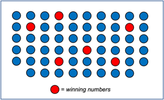

In order to determine whether the grand prize can cover all the expenses if the bettor were to try all the possible combinations, it is necessary to compute the number of possible combinations first. Since order is not important in guessing for the winning numbers, **the formula for combination is more appropriate** as seen below:

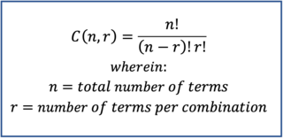

Since there are 58 total number of terms to pick from and there are 6 numbers to pick per ticket, solving for the **number of possible combinations** would look like:

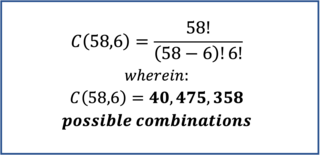

With the number of possible combinations now available, we can now proceed to solving for the **total amount to be spent** if each ticket were to cost 20 pesos.

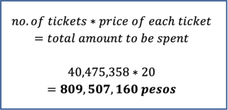

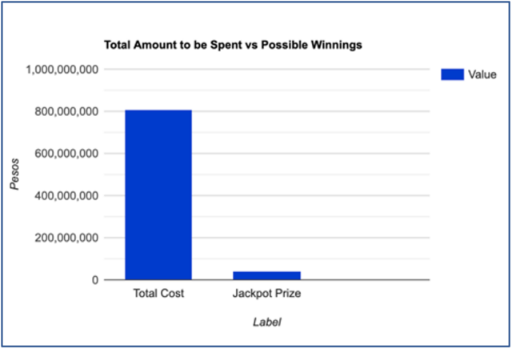